# 001_Chapter5_DD

Dina D.

2022-11-04

# Chapter 5: The forecaster’s toolbox

# 5.1: A tidy forecasting workflow

Process of producing forecasts: tidy->visualize->specify->estimate->evaluate->forecast

First step: prepare data in right format This process may involve loading in data, identifying missing values, filtering the time series, and other pre-processing tasks. Packages like tsibble and tidyvers simplifies this step.

Many models have data requirements like some need to be in time order or have no missing values

*This models GDP per capita over time

```r
gdppc <- global_economy %>%
  mutate(GDP_per_capita = GDP / Population)
```

*Plotting gdppc

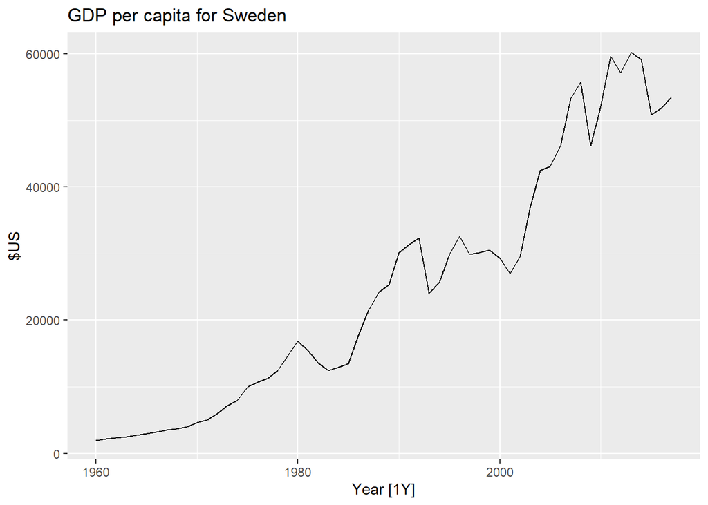

```r
gdppc %>%
  filter(Country == "Sweden") %>%
  autoplot(GDP_per_capita) +
  labs(y = "$US", title = "GDP per capita for Sweden")
```

Next step after plotting is defining a model A linear trend model can be specified with

```r
TSLM(GDP_per_capita ~ trend())
```

```
## <TSLM model definition>
```

Next step is training the model (estimate)

```r
fit <- gdppc %>%
  model(trend_model = TSLM(GDP_per_capita ~ trend()))
fit
```

```
## # A mable: 263 x 2
## # Key:     Country [263]
##    Country             trend_model
##    <fct>                   <model>
##  1 Afghanistan              <TSLM>
##  2 Albania                  <TSLM>
##  3 Algeria                  <TSLM>
##  4 American Samoa           <TSLM>
##  5 Andorra                  <TSLM>
##  6 Angola                   <TSLM>
##  7 Antigua and Barbuda      <TSLM>
##  8 Arab World               <TSLM>
##  9 Argentina                <TSLM>
## 10 Armenia                  <TSLM>
## # … with 253 more rows
```

Next step is check the model’s performance (evaluate)

Now we can produce a forecast. With an appropriate model specified, estimated and checked, it is time to produce the forecasts using forecast(). The easiest way to use this function is by specifying the number of future observations to forecast. For example, forecasts for the next 10 observations can be generated using h = 10.

```r
fit %>% forecast(h = 3)
```

```
## # A fable: 789 x 5 [1Y]
## # Key:     Country, .model [263]
##    Country        .model       Year   GDP_per_capita  .mean
##    <fct>          <chr>       <dbl>           <dist>  <dbl>
##  1 Afghanistan    trend_model  2018     N(526, 9653)   526.
##  2 Afghanistan    trend_model  2019     N(534, 9689)   534.
##  3 Afghanistan    trend_model  2020     N(542, 9727)   542.
##  4 Albania        trend_model  2018  N(4716, 476419)  4716.
##  5 Albania        trend_model  2019  N(4867, 481086)  4867.
##  6 Albania        trend_model  2020  N(5018, 486012)  5018.
##  7 Algeria        trend_model  2018  N(4410, 643094)  4410.
##  8 Algeria        trend_model  2019  N(4489, 645311)  4489.
##  9 Algeria        trend_model  2020  N(4568, 647602)  4568.
## 10 American Samoa trend_model  2018 N(12491, 652926) 12491.
## # … with 779 more rows
```

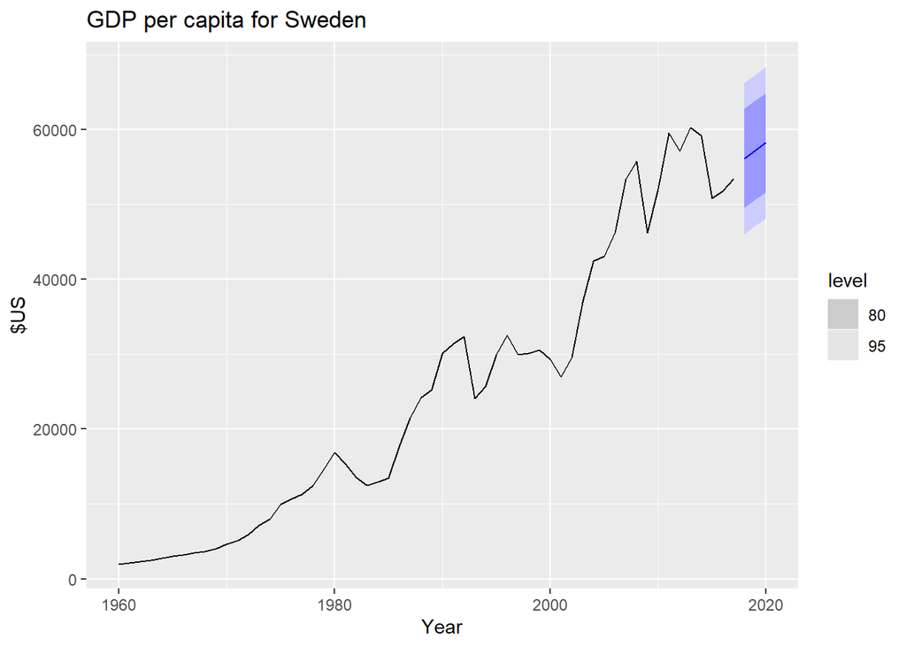

```r
fit %>%
  forecast(h = "3 years") %>%
  filter(Country == "Sweden") %>%
  autoplot(gdppc) +
  labs(y = "$US", title = "GDP per capita for Sweden")
```

```r
fit2<-gdppc %>%
  filter(Country == "Sweden") %>%
  filter_index("1960"~"2015")
fit2 %>% model(MEAN(fit2))
```

```
## # A mable: 1 x 2
## # Key:     Country [1]
##   Country `MEAN(fit2)`
##   <fct>        <model>
## 1 Sweden  <NULL model>
```

# 5.2: SOme forecasting methods

*The filter_index() function is a convenient shorthand for extracting a section of a time series.

```r
bricks <- aus_production %>%
  filter_index("1970 Q1" ~ "2004 Q4") %>%
  select(Bricks)
```

Mean method: -forecasts of all future values are equal to the average (or “mean”) of the historical data.

```r
bricks %>% model(MEAN(Bricks))
```

```
## # A mable: 1 x 1
##   `MEAN(Bricks)`
##          <model>
## 1         <MEAN>
```

Naïve method: -set all forecasts to be the value of the last observation. -This method works remarkably well for many economic and financial time series.

```r
bricks %>% model(NAIVE(Bricks))
```

```
## # A mable: 1 x 1
##   `NAIVE(Bricks)`
##           <model>
## 1         <NAIVE>
```

Because a naïve forecast is optimal when data follow a random walk, these are also called random walk forecasts and the RW() function can be used instead of NAIVE.

Seasonal naïve method: -similar method is useful for highly seasonal data. In this case, we set each forecast to be equal to the last observed value from the same season (e.g., the same month of the previous year) - For example, with monthly data, the forecast for all future February values is equal to the last observed February value. With quarterly data, the forecast of all future Q2 values is equal to the last observed Q2 value

```r
bricks %>% model(SNAIVE(Bricks ~ lag("year")))
```

```
## # A mable: 1 x 1
##   `SNAIVE(Bricks ~ lag("year"))`
##                          <model>
## 1                       <SNAIVE>
```

The lag() function is optional here as bricks is quarterly data and so a seasonal naïve method will need a one-year lag.

Drift method: -drawing a line between the first and last observations, and extrapolating it into the future.

```r
bricks %>% model(RW(Bricks ~ drift()))
```

```
## # A mable: 1 x 1
##   `RW(Bricks ~ drift())`
##                  <model>
## 1          <RW w/ drift>
```

Example of all three methods shown in one plot: Australian quarterly beer production:

```
## Plot variable not specified, automatically selected `.vars = Beer`
```

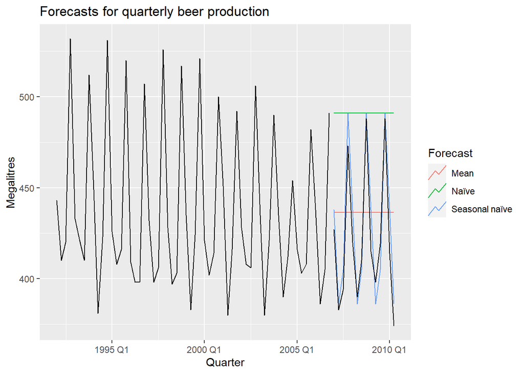

```r
# Set training data from 1992 to 2006
train <- aus_production %>%
  filter_index("1992 Q1" ~ "2006 Q4")
# Fit the models
beer_fit <- train %>%
  model(
    Mean = MEAN(Beer),
    `Naïve` = NAIVE(Beer),
    `Seasonal naïve` = SNAIVE(Beer)
  )
# Generate forecasts for 14 quarters
beer_fc <- beer_fit %>% forecast(h = 14)
# Plot forecasts against actual values
beer_fc %>%
  autoplot(train, level = NULL) +
  autolayer(
    filter_index(aus_production, "2007 Q1" ~ .),
    colour = "black"
  ) +
  labs(
    y = "Megalitres",
    title = "Forecasts for quarterly beer production"
  ) +
  guides(colour = guide_legend(title = "Forecast"))
```

Google’s daily closing stock price:

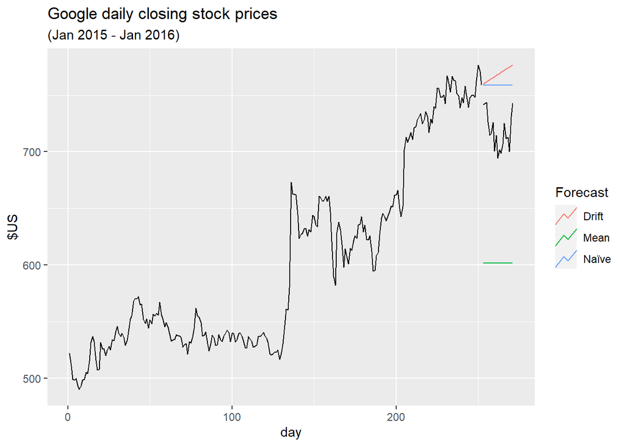

```r
# Re-index based on trading days
google_stock <- gafa_stock %>%
  filter(Symbol == "GOOG", year(Date) >= 2015) %>%
  mutate(day = row_number()) %>%
  update_tsibble(index = day, regular = TRUE)
# Filter the year of interest
google_2015 <- google_stock %>% filter(year(Date) == 2015)
# Fit the models
google_fit <- google_2015 %>%
  model(
    Mean = MEAN(Close),
    `Naïve` = NAIVE(Close),
    Drift = NAIVE(Close ~ drift())
  )
# Produce forecasts for the trading days in January 2016
google_jan_2016 <- google_stock %>%
  filter(yearmonth(Date) == yearmonth("2016 Jan"))
google_fc <- google_fit %>%
  forecast(new_data = google_jan_2016)
# Plot the forecasts
google_fc %>%
  autoplot(google_2015, level = NULL) +
  autolayer(google_jan_2016, Close, colour = "black") +
  labs(y = "$US",
       title = "Google daily closing stock prices",
       subtitle = "(Jan 2015 - Jan 2016)") +
  guides(colour = guide_legend(title = "Forecast"))
```

# 5.3: Fitted values and residuals

-Each observation in a time series can be forecast using all previous observations. We call these fitted values - fitted values are often not true forecasts because any parameters involved in the forecasting method are estimated using all available observations in the time series, including future observations. -When the estimate of c involves observations after time t, the fitted values are not true forecasts. On the other hand, naïve or seasonal naïve forecasts do not involve any parameters, and so fitted values are true forecasts in such cases. ^- A little confused on understanding what these statements is saying

The “residuals” in a time series model are what is left over after fitting a model. -The residuals are equal to the difference between the observations and the corresponding fitted values

The fitted values and residuals from a model can be obtained using the augment() function.

```r
augment(beer_fit)
```

```
## # A tsibble: 180 x 6 [1Q]
## # Key:       .model [3]
##    .model Quarter  Beer .fitted .resid .innov
##    <chr>    <qtr> <dbl>   <dbl>  <dbl>  <dbl>
##  1 Mean   1992 Q1   443    436.   6.55   6.55
##  2 Mean   1992 Q2   410    436. -26.4  -26.4
##  3 Mean   1992 Q3   420    436. -16.4  -16.4
##  4 Mean   1992 Q4   532    436.  95.6   95.6
##  5 Mean   1993 Q1   433    436.  -3.45  -3.45
##  6 Mean   1993 Q2   421    436. -15.4  -15.4
##  7 Mean   1993 Q3   410    436. -26.4  -26.4
##  8 Mean   1993 Q4   512    436.  75.6   75.6
##  9 Mean   1994 Q1   449    436.  12.6   12.6
## 10 Mean   1994 Q2   381    436. -55.4  -55.4
## # … with 170 more rows
```

- .fitted contains the fitted values;
- .resid contains the residuals;
- .innov contains the “innovation residuals” which, in this case, are identical to the regular residuals.

Residuals are useful in checking whether a model has adequately captured the information in the data. For this purpose, we use innovation residuals.

If patterns are observable in the innovation residuals, the model can probably be improved.